## "Predictive Modeling for Heart Attack Risk Assessment using Machine Learning"

**Introduction:** Cardiovascular diseases (CVDs) are a leading cause of morbidity and mortality worldwide, imposing a significant burden on healthcare systems and economies. Early detection and accurate risk assessment are essential for effective prevention and management of CVDs. In recent years, predictive modeling techniques leveraging machine learning algorithms have emerged as promising tools for assessing an individual's risk of developing cardiovascular conditions, such as heart attacks. This study focuses on utilizing a comprehensive set of objective and subjective features to develop predictive models for heart attack risk assessment.

The dataset includes objective features such as age, height, weight, gender, systolic and diastolic blood pressure, as well as examination features like cholesterol and glucose levels. Additionally, subjective features such as smoking, alcohol intake, and physical activity are incorporated. These features provide a multifaceted view of an individual's health status and lifestyle factors that may influence cardiovascular health.

By harnessing the power of machine learning, we aim to develop accurate and interpretable predictive models that can effectively identify individuals at elevated risk of experiencing a heart attack. These models have the potential to assist healthcare professionals in early intervention and personalized preventative strategies, ultimately contributing to the reduction of CVD-related morbidity and mortality.

### Features:

- Age | Objective Feature | age | int (days)
- Height | Objective Feature | height | int (cm) |
- Weight | Objective Feature | weight | float (kg) |
- Gender | Objective Feature | gender | categorical code |
- Systolic blood pressure | Examination Feature | ap_hi | int |
- Diastolic blood pressure | Examination Feature | ap_lo | int |
- Cholesterol | Examination Feature | cholesterol | 1: normal, 2: above normal, 3: well above normal |
- Glucose | Examination Feature | gluc | 1: normal, 2: above normal, 3: well above normal |
- Smoking | Subjective Feature | smoke | binary | 0: Non-Smoker, 1: Smoker
- Alcohol intake | Subjective Feature | alco | binary | 0: Non-alcoholic, 1: Alcoholic
- Physical activity | Subjective Feature | active | binary | 0: Inactive, 1:Active
- Presence or absence of cardiovascular disease | Target Variable | cardio | binary | 0: No Heart disease, 1: Heart disease

```python
import pandas as pd
import numpy as np
from sklearn.metrics import classification_report
from imblearn.over_sampling import SMOTE
from sklearn.datasets import make_classification
from sklearn.model_selection import train_test_split
from sklearn.model_selection import train_test_split, cross_val_score, GridSearchCV
from sklearn.svm import SVC
import matplotlib.pyplot as plt
from sklearn.ensemble import RandomForestClassifier
```

```python
import pandas as pd

# Read CSV specifying semicolon as the delimiter
df = pd.read_csv(r"D:\MIT_Capstone_project\Heart_risk_prediction\archive\cardio_train.csv", delimiter=';')

# Remove semicolons from column names
df.columns = df.columns.str.replace(';', '')
df.head()
```

|  | id | age | gender | height | weight | ap_hi | ap_lo | cholesterol | gluc | smoke | alco | active | cardio |
| --- | --- | --- | --- | --- | --- | --- | --- | --- | --- | --- | --- | --- | --- |
| 0 | 0 | 18393 | 2 | 168 | 62.0 | 110 | 80 | 1 | 1 | 0 | 0 | 1 | 0 |
| 1 | 1 | 20228 | 1 | 156 | 85.0 | 140 | 90 | 3 | 1 | 0 | 0 | 1 | 1 |
| 2 | 2 | 18857 | 1 | 165 | 64.0 | 130 | 70 | 3 | 1 | 0 | 0 | 0 | 1 |
| 3 | 3 | 17623 | 2 | 169 | 82.0 | 150 | 100 | 1 | 1 | 0 | 0 | 1 | 1 |
| 4 | 4 | 17474 | 1 | 156 | 56.0 | 100 | 60 | 1 | 1 | 0 | 0 | 0 | 0 |

```python
df.head()
```

|  | id | age | gender | height | weight | ap_hi | ap_lo | cholesterol | gluc | smoke | alco | active | cardio |
| --- | --- | --- | --- | --- | --- | --- | --- | --- | --- | --- | --- | --- | --- |
| 0 | 0 | 18393 | 2 | 168 | 62.0 | 110 | 80 | 1 | 1 | 0 | 0 | 1 | 0 |
| 1 | 1 | 20228 | 1 | 156 | 85.0 | 140 | 90 | 3 | 1 | 0 | 0 | 1 | 1 |
| 2 | 2 | 18857 | 1 | 165 | 64.0 | 130 | 70 | 3 | 1 | 0 | 0 | 0 | 1 |
| 3 | 3 | 17623 | 2 | 169 | 82.0 | 150 | 100 | 1 | 1 | 0 | 0 | 1 | 1 |
| 4 | 4 | 17474 | 1 | 156 | 56.0 | 100 | 60 | 1 | 1 | 0 | 0 | 0 | 0 |

```python
# Divide 'age' column values by 365 and convert to integers
df['age'] = (df['age'] / 365).astype(int)
```

```python
df.head()
```

|  | id | age | gender | height | weight | ap_hi | ap_lo | cholesterol | gluc | smoke | alco | active | cardio |
| --- | --- | --- | --- | --- | --- | --- | --- | --- | --- | --- | --- | --- | --- |
| 0 | 0 | 50 | 2 | 168 | 62.0 | 110 | 80 | 1 | 1 | 0 | 0 | 1 | 0 |
| 1 | 1 | 55 | 1 | 156 | 85.0 | 140 | 90 | 3 | 1 | 0 | 0 | 1 | 1 |
| 2 | 2 | 51 | 1 | 165 | 64.0 | 130 | 70 | 3 | 1 | 0 | 0 | 0 | 1 |
| 3 | 3 | 48 | 2 | 169 | 82.0 | 150 | 100 | 1 | 1 | 0 | 0 | 1 | 1 |
| 4 | 4 | 47 | 1 | 156 | 56.0 | 100 | 60 | 1 | 1 | 0 | 0 | 0 | 0 |

```python
# Replace 'edited_file.csv' with the desired name of the output CSV file
output_csv_file = 'heart_dataset.csv'

# Save the DataFrame to a CSV file
df.to_csv(output_csv_file, index=False)

print("DataFrame saved to", output_csv_file)
```

```
DataFrame saved to heart_dataset.csv
```

```python
df.describe()
```

|  | id | age | gender | height | weight | ap_hi | ap_lo | cholesterol | gluc | smoke | alco | active | cardio |
| --- | --- | --- | --- | --- | --- | --- | --- | --- | --- | --- | --- | --- | --- |
| count | 70000.000000 | 70000.000000 | 70000.000000 | 70000.000000 | 70000.000000 | 70000.000000 | 70000.000000 | 70000.000000 | 70000.000000 | 70000.000000 | 70000.000000 | 70000.000000 | 70000.000000 |
| mean | 49972.419900 | 52.840671 | 1.349571 | 164.359229 | 74.205690 | 128.817286 | 96.630414 | 1.366871 | 1.226457 | 0.088129 | 0.053771 | 0.803729 | 0.499700 |
| std | 28851.302323 | 6.766774 | 0.476838 | 8.210126 | 14.395757 | 154.011419 | 188.472530 | 0.680250 | 0.572270 | 0.283484 | 0.225568 | 0.397179 | 0.500003 |
| min | 0.000000 | 29.000000 | 1.000000 | 55.000000 | 10.000000 | -150.000000 | -70.000000 | 1.000000 | 1.000000 | 0.000000 | 0.000000 | 0.000000 | 0.000000 |
| 25% | 25006.750000 | 48.000000 | 1.000000 | 159.000000 | 65.000000 | 120.000000 | 80.000000 | 1.000000 | 1.000000 | 0.000000 | 0.000000 | 1.000000 | 0.000000 |
| 50% | 50001.500000 | 53.000000 | 1.000000 | 165.000000 | 72.000000 | 120.000000 | 80.000000 | 1.000000 | 1.000000 | 0.000000 | 0.000000 | 1.000000 | 0.000000 |
| 75% | 74889.250000 | 58.000000 | 2.000000 | 170.000000 | 82.000000 | 140.000000 | 90.000000 | 2.000000 | 1.000000 | 0.000000 | 0.000000 | 1.000000 | 1.000000 |
| max | 99999.000000 | 64.000000 | 2.000000 | 250.000000 | 200.000000 | 16020.000000 | 11000.000000 | 3.000000 | 3.000000 | 1.000000 | 1.000000 | 1.000000 | 1.000000 |

```python
### Checking for missing values
print(df.isnull().sum())
```

```
id             0
age            0
gender         0
height         0
weight         0
ap_hi          0
ap_lo          0
cholesterol    0
gluc           0
smoke          0
alco           0
active         0
cardio         0
dtype: int64
```

```python
df.info()
```

```
<class 'pandas.core.frame.DataFrame'>
RangeIndex: 70000 entries, 0 to 69999
Data columns (total 13 columns):
 #   Column       Non-Null Count  Dtype
---  ------       --------------  -----
 0   id           70000 non-null  int64
 1   age          70000 non-null  int32
 2   gender       70000 non-null  int64
 3   height       70000 non-null  int64
 4   weight       70000 non-null  float64
 5   ap_hi        70000 non-null  int64
 6   ap_lo        70000 non-null  int64
 7   cholesterol  70000 non-null  int64
 8   gluc         70000 non-null  int64
 9   smoke        70000 non-null  int64
 10  alco         70000 non-null  int64
 11  active       70000 non-null  int64
 12  cardio       70000 non-null  int64
dtypes: float64(1), int32(1), int64(11)
memory usage: 6.7 MB
```

```python
df.columns
```

[output not shown]

```python
# Checking the column names to ensure 'id' exists
print(df.columns)

# Drop the 'id' column if it exists
if 'id' in df.columns:
    df = df.drop(columns=['id'])
else:
    print("Column 'id' does not exist in the DataFrame.")
```

```
Index(['age', 'gender', 'height', 'weight', 'ap_hi', 'ap_lo', 'cholesterol',
       'gluc', 'smoke', 'alco', 'active', 'cardio'],
      dtype='object')
Column 'id' does not exist in the DataFrame.
```

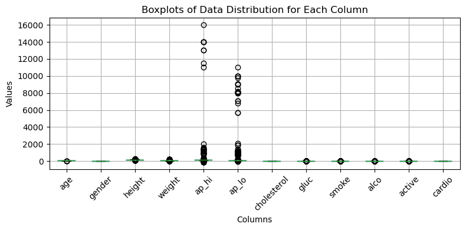

```python
# Plot boxplots for each column
plt.figure(figsize=(8, 4))  # Adjust figure size if needed
df.boxplot()
plt.xticks(rotation=45)  # Rotate x-axis labels for better readability
plt.title('Boxplots of Data Distribution for Each Column')
plt.xlabel('Columns')
plt.ylabel('Values')
plt.tight_layout()  # Adjust layout to prevent clipping of labels
plt.show()
```

[figure not shown]

```python
cols = ['age', 'gender', 'height', 'weight', 'ap_hi', 'ap_lo',
        'cholesterol', 'gluc', 'smoke', 'alco', 'active', 'cardio']
nrows = 4
ncols = 3

# Create subplots
fig, ax = plt.subplots(nrows, ncols, figsize=(15, 10))

# Flatten the axes array to iterate over each subplot
ax = ax.flatten()

# Plot box plots for each column
for i, col in enumerate(cols):
    sns.boxplot(x=df[col], ax=ax[i], color='green')
    ax[i].set_title(col)

# Hide any remaining empty subplots
for j in range(len(cols), nrows * ncols):
    ax[j].axis('off')

# Adjust layout
plt.tight_layout()

# Show the plots
plt.show()
```

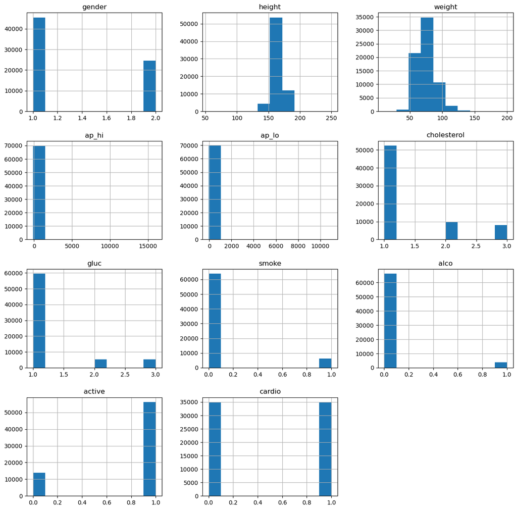

```python
df.iloc[:,1:].hist(figsize=(15,15));
```

### Display the distibution of the continuous data columns

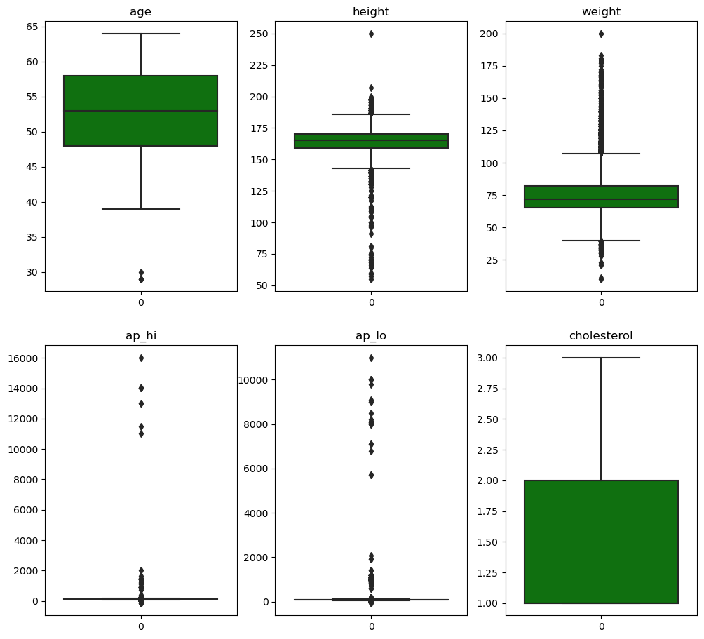

```python
cols = ['age', 'height', 'weight', 'ap_hi', 'ap_lo',
       'cholesterol']
nrows=2
ncols=3
fig, ax = plt.subplots(nrows, ncols, figsize=(12, 11))
cont = 0
for i in range(nrows):
    for j in range(ncols):
        sns.boxplot(df[cols[cont]], ax=ax[i][j], color='green')
        ax[i][j].set_title(cols[cont])
        cont = cont + 1
```

To enhance the predictive performance of our models, we've implemented outlier removal, specifically targeting instances falling outside the range of 2.5% to 97.5% for features including ap_hi, ap_lo, weight, and height. Also, the id column has been removed as it has no role in predicting the disease. Following this process, the dataset has been refined from 70,000 to 55,403 records.

```python
### Outlier Removal
df.drop(df[(df['height'] > df['height'].quantile(0.975)) | (df['height'] < df['height'].quantile(0.025))].index,inplace=True)
df.drop(df[(df['weight'] > df['weight'].quantile(0.975)) | (df['weight'] < df['weight'].quantile(0.025))].index,inplace=True)
df.drop(df[(df['ap_hi'] > df['ap_hi'].quantile(0.975)) | (df['ap_hi'] < df['ap_hi'].quantile(0.025))].index,inplace=True)
df.drop(df[(df['ap_lo'] > df['ap_lo'].quantile(0.975)) | (df['ap_lo'] < df['ap_lo'].quantile(0.025))].index,inplace=True)
len(df)
```

```
55403
```

```python
df.describe()
```

|  | age | gender | height | weight | ap_hi | ap_lo | cholesterol | gluc | smoke | alco | active | cardio |
| --- | --- | --- | --- | --- | --- | --- | --- | --- | --- | --- | --- | --- |
| count | 55403.000000 | 55403.000000 | 55403.000000 | 55403.000000 | 55403.000000 | 55403.000000 | 55403.000000 | 55403.000000 | 55403.000000 | 55403.000000 | 55403.000000 | 55403.000000 |
| mean | 52.835948 | 1.345631 | 164.657365 | 73.219197 | 125.702417 | 81.019241 | 1.346100 | 1.218400 | 0.084508 | 0.051207 | 0.803910 | 0.487356 |
| std | 6.728496 | 0.475578 | 6.249940 | 10.612557 | 13.658446 | 8.182584 | 0.666956 | 0.566398 | 0.278151 | 0.220421 | 0.397041 | 0.499845 |
| min | 29.000000 | 1.000000 | 152.000000 | 55.000000 | 100.000000 | 60.000000 | 1.000000 | 1.000000 | 0.000000 | 0.000000 | 0.000000 | 0.000000 |
| 25% | 48.000000 | 1.000000 | 160.000000 | 65.000000 | 120.000000 | 80.000000 | 1.000000 | 1.000000 | 0.000000 | 0.000000 | 1.000000 | 0.000000 |
| 50% | 53.000000 | 1.000000 | 165.000000 | 72.000000 | 120.000000 | 80.000000 | 1.000000 | 1.000000 | 0.000000 | 0.000000 | 1.000000 | 0.000000 |
| 75% | 58.000000 | 2.000000 | 169.000000 | 80.000000 | 130.000000 | 90.000000 | 1.000000 | 1.000000 | 0.000000 | 0.000000 | 1.000000 | 1.000000 |
| max | 64.000000 | 2.000000 | 178.000000 | 100.000000 | 160.000000 | 100.000000 | 3.000000 | 3.000000 | 1.000000 | 1.000000 | 1.000000 | 1.000000 |

```python
# Create a correlation matrix
corr_matrix = df[['age', 'gender', 'height', 'weight', 'ap_hi',
       'ap_lo', 'cholesterol', 'gluc', 'smoke', 'alco',
       'active', 'cardio']].corr()
corr_matrix
```

|  | age | gender | height | weight | ap_hi | ap_lo | cholesterol | gluc | smoke | alco | active | cardio |
| --- | --- | --- | --- | --- | --- | --- | --- | --- | --- | --- | --- | --- |
| age | 1.000000 | -0.020389 | -0.079134 | 0.065947 | 0.201000 | 0.144204 | 0.149812 | 0.096004 | -0.045087 | -0.026770 | -0.011711 | 0.234718 |
| gender | -0.020389 | 1.000000 | 0.483103 | 0.109261 | 0.044317 | 0.047453 | -0.041454 | -0.024802 | 0.336452 | 0.167098 | 0.010413 | -0.003142 |
| height | -0.079134 | 0.483103 | 1.000000 | 0.211756 | -0.013698 | 0.000893 | -0.071902 | -0.034959 | 0.179969 | 0.082309 | 0.000135 | -0.031319 |
| weight | 0.065947 | 0.109261 | 0.211756 | 1.000000 | 0.218430 | 0.198896 | 0.127192 | 0.083419 | 0.053421 | 0.053070 | -0.004706 | 0.148986 |
| ap_hi | 0.201000 | 0.044317 | -0.013698 | 0.218430 | 1.000000 | 0.693012 | 0.185035 | 0.080021 | 0.020949 | 0.021933 | 0.004134 | 0.426848 |
| ap_lo | 0.144204 | 0.047453 | 0.000893 | 0.198896 | 0.693012 | 1.000000 | 0.144580 | 0.059876 | 0.017336 | 0.023742 | 0.002739 | 0.319660 |
| cholesterol | 0.149812 | -0.041454 | -0.071902 | 0.127192 | 0.185035 | 0.144580 | 1.000000 | 0.455696 | 0.003460 | 0.022605 | 0.004433 | 0.214999 |
| gluc | 0.096004 | -0.024802 | -0.034959 | 0.083419 | 0.080021 | 0.059876 | 0.455696 | 1.000000 | -0.011520 | -0.000087 | -0.008532 | 0.084284 |
| smoke | -0.045087 | 0.336452 | 0.179969 | 0.053421 | 0.020949 | 0.017336 | 0.003460 | -0.011520 | 1.000000 | 0.342758 | 0.026003 | -0.021136 |
| alco | -0.026770 | 0.167098 | 0.082309 | 0.053070 | 0.021933 | 0.023742 | 0.022605 | -0.000087 | 0.342758 | 1.000000 | 0.025638 | -0.016486 |
| active | -0.011711 | 0.010413 | 0.000135 | -0.004706 | 0.004134 | 0.002739 | 0.004433 | -0.008532 | 0.026003 | 0.025638 | 1.000000 | -0.038050 |
| cardio | 0.234718 | -0.003142 | -0.031319 | 0.148986 | 0.426848 | 0.319660 | 0.214999 | 0.084284 | -0.021136 | -0.016486 | -0.038050 | 1.000000 |

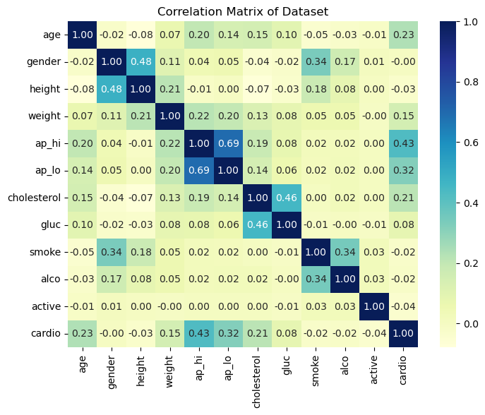

```python
# Plotting the heatmap
plt.figure(figsize=(8, 6))
sns.heatmap(corr_matrix, annot=True, fmt=".2f", cmap='YlGnBu', cbar=True)
plt.title('Correlation Matrix of Dataset');
```

```python
df.info()
```

```
<class 'pandas.core.frame.DataFrame'>
Index: 55403 entries, 0 to 69999
Data columns (total 12 columns):
 #   Column       Non-Null Count  Dtype
---  ------       --------------  -----
 0   age          55403 non-null  int32
 1   gender       55403 non-null  int64
 2   height       55403 non-null  int64
 3   weight       55403 non-null  float64
 4   ap_hi        55403 non-null  int64
 5   ap_lo        55403 non-null  int64
 6   cholesterol  55403 non-null  int64
 7   gluc         55403 non-null  int64
 8   smoke        55403 non-null  int64
 9   alco         55403 non-null  int64
 10  active       55403 non-null  int64
 11  cardio       55403 non-null  int64
dtypes: float64(1), int32(1), int64(10)
memory usage: 5.3 MB
```

```python
value_count = df["cardio"].value_counts()
value_count
```

```
cardio
0    28402
1    27001
Name: count, dtype: int64
```

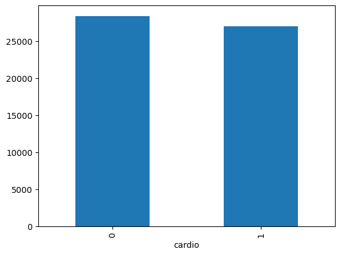

```python
df["cardio"].value_counts().plot(kind="bar")
plt.show()
```

## First Split

```python
## x and y
X=df[['age', 'gender', 'height', 'weight', 'ap_hi', 'ap_lo', 'cholesterol',
       'gluc', 'smoke', 'alco', 'active']]
X.shape
```

```
(55403, 11)
```

```python
y=df['cardio']
y.shape
```

```
(55403,)
```

```python
features=X.columns
features
```

```
Index(['age', 'gender', 'height', 'weight', 'ap_hi', 'ap_lo', 'cholesterol',
       'gluc', 'smoke', 'alco', 'active'],
      dtype='object')
```

```python
### create test and train and SMOTE the X matrices
os=SMOTE(random_state=0)
X_os, y_os = os.fit_resample (X,y)
```

```python
X_os.shape, y_os.shape
```

```
((56804, 11), (56804,))
```

```python
y_os.value_counts(normalize=True)
```

```
cardio
0    0.5
1    0.5
Name: proportion, dtype: float64
```

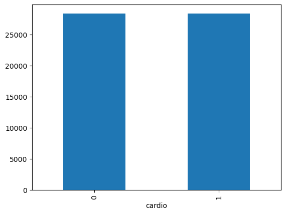

```python
y_os.value_counts().plot(kind="bar")
plt.show()
```

```python
df_os = pd.DataFrame(X_os)
df_os["cardio"] = y_os
```

```python
y_os.head(10)
```

```
0    0
1    1
2    1
3    1
4    0
5    0
6    1
7    0
8    0
9    0
Name: cardio, dtype: int64
```

```python
y_os.shape
```

```
(56804,)
```

```python
X_os.head(10)
```

|  | age | gender | height | weight | ap_hi | ap_lo | cholesterol | gluc | smoke | alco | active |
| --- | --- | --- | --- | --- | --- | --- | --- | --- | --- | --- | --- |
| 0 | 50 | 2 | 168 | 62.0 | 110 | 80 | 1 | 1 | 0 | 0 | 1 |
| 1 | 55 | 1 | 156 | 85.0 | 140 | 90 | 3 | 1 | 0 | 0 | 1 |
| 2 | 51 | 1 | 165 | 64.0 | 130 | 70 | 3 | 1 | 0 | 0 | 0 |
| 3 | 48 | 2 | 169 | 82.0 | 150 | 100 | 1 | 1 | 0 | 0 | 1 |
| 4 | 47 | 1 | 156 | 56.0 | 100 | 60 | 1 | 1 | 0 | 0 | 0 |
| 5 | 60 | 1 | 157 | 93.0 | 130 | 80 | 3 | 1 | 0 | 0 | 1 |
| 6 | 61 | 2 | 178 | 95.0 | 130 | 90 | 3 | 3 | 0 | 0 | 1 |
| 7 | 48 | 1 | 158 | 71.0 | 110 | 70 | 1 | 1 | 0 | 0 | 1 |
| 8 | 54 | 1 | 164 | 68.0 | 110 | 60 | 1 | 1 | 0 | 0 | 0 |
| 9 | 61 | 1 | 169 | 80.0 | 120 | 80 | 1 | 1 | 0 | 0 | 1 |

```python
X_os.shape
```

```
(56804, 11)
```

## 2nd Split (train & test)

```python
## Scaling train features for optimal model performance
scaler_std = StandardScaler()
X_standardized = scaler_std.fit_transform(X_os)
```

```python
X_standardized.shape, y_os.shape
```

```
((56804, 11), (56804,))
```

```python
X_standardized
```

```
array([[-0.42546109,  1.38777871,  0.53763847, ..., -0.30016595,
        -0.22944974,  0.49904258],
       [ 0.31847308, -0.72057598, -1.38392293, ..., -0.30016595,
        -0.22944974,  0.49904258],
       [-0.27667425, -0.72057598,  0.05724812, ..., -0.30016595,
        -0.22944974, -2.00383704],
       ...,
       [-0.42546109, -0.72057598, -0.42314223, ..., -0.30016595,
        -0.22944974,  0.49904258],
       [ 1.50876774, -0.72057598,  0.85789871, ..., -0.30016595,
        -0.22944974,  0.49904258],
       [-1.02060842,  1.38777871,  1.17815894, ..., -0.30016595,
        -0.22944974,  0.49904258]])
```

```python
X_train, y_train, X_test, y_test = train_test_split(X_standardized, y_os, test_size=0.2, random_state=0)
```

## Training the model

### 1. Logistic Regression Classifier

```python
## creating the instance of logistic regression model
model_lr= LogisticRegression(solver="liblinear")

## use train data to train the model features:
model_lr.fit(X_standardized, y_os)

# Display the train and test scores
print('Train Accuracy: ', model_lr.score(X_standardized, y_os))
print('Test Accuracy: ', model_lr.score(X_standardized, y_os))
```

```
Train Accuracy:  0.7195620026758679
Test Accuracy:  0.7195620026758679
```

```python
cross_val_score(LogisticRegression(),X_standardized,y_os)
```

```
array([0.71833465, 0.719831  , 0.72009506, 0.72220755, 0.71399648])
```

### 2. Support Vector Classifier

```python
# Load the SVC model
svc_model = SVC()

# Train the SVC model
svc_model.fit(X_standardized, y_os)

# Display the train and test scores
print('Train Accuracy:', svc_model.score(X_standardized, y_os))
print('Test Accuracy:', svc_model.score(X_standardized, y_os))
```

```
Train Accuracy: 0.7288395183437786
Test Accuracy: 0.7288395183437786
```

### 3. Gaussian NB Classifier

```python
## Load the Gaussian NB Model
from sklearn.naive_bayes import GaussianNB
nb_classifier = GaussianNB()

## Train the model
nb_classifier.fit(X_standardized, y_os)

NB_classifier_scores = cross_val_score(nb_classifier, X_standardized, y_os, cv=5)

# Display the train and test scores
print('Train Accuracy:', nb_classifier.score(X_standardized, y_os))
print('Test Accuracy:', nb_classifier.score(X_standardized, y_os))
```

```
Train Accuracy: 0.7054960918245194
Test Accuracy: 0.7054960918245194
```

### 4. K Neighbors Classifier

```python
from sklearn.neighbors import KNeighborsClassifier

# Load the KNN model
knn_model = KNeighborsClassifier()

# Train the KNN model
knn_model.fit(X_standardized, y_os)

# Display the train and test scores
print('Train Accuracy:', knn_model.score(X_standardized, y_os))
print('Test Accuracy:', knn_model.score(X_standardized, y_os))
```

```
Train Accuracy: 0.7800330962608267
Test Accuracy: 0.7800330962608267
```

### 5. Gradient Boosting Classifier

```python
### load and train the model
gbc = GradientBoostingClassifier()
gbc.fit(X_standardized, y_os)

### Display the train and test scores
print('Train Accuracy: ',gbc.score(X_standardized, y_os))
print('Test Accuracy: ', gbc.score(X_standardized, y_os))
```

```
Train Accuracy:  0.728082529399338
Test Accuracy:  0.728082529399338
```

```python
cross_val_score(GradientBoostingClassifier(),X_standardized,y_os)
```

```
array([0.72396796, 0.73021741, 0.72528827, 0.72731274, 0.7215669 ])
```

### 6. Random Forest Classifier

```python
### load and train the model
rf = RandomForestClassifier()
rf.fit(X_standardized, y_os)

### Display the train and test scores
print('Train Accuracy: ', rf.score(X_standardized, y_os))
print('Test Accuracy: ', rf.score(X_standardized, y_os))
```

```
Train Accuracy:  0.972079431025984
Test Accuracy:  0.972079431025984
```

```python
# Make predictions on the test set
logistic_preds = model_lr.predict(X_standardized)
forest_preds = rf.predict(X_standardized)
boosting_preds = gbc.predict(X_standardized)
knn_preds=knn_model.predict(X_standardized)
svm_preds=svc_model.predict(X_standardized)
NB_classifier_pred=nb_classifier.predict(X_standardized)
```

## Model Evaluation

```python
from sklearn.metrics import accuracy_score, roc_auc_score, confusion_matrix, classification_report
def evaluate_model(predictions, model_name):
    print(f"Results for {model_name}:")
    print("Accuracy:", accuracy_score(y_os, predictions))
    print("ROC-AUC:", roc_auc_score(y_os, predictions))
    print("Confusion Matrix:\n", confusion_matrix(y_os, predictions))
    print("Classification Report:\n", classification_report(y_os, predictions))
    print("-" * 50)
```

```python
# Evaluate each model
evaluate_model(logistic_preds, "Logistic Regression")
evaluate_model(forest_preds, "Random Forest Classifier")
evaluate_model(boosting_preds, "Gradient Boosting Classifier")
evaluate_model(knn_preds, "K Neighbors Classifier")
evaluate_model(svm_preds, "Support Vector Classifier")
evaluate_model(NB_classifier_pred, "NB Classifier")
```

```
Results for Logistic Regression:
Accuracy: 0.7195620026758679
ROC-AUC: 0.7195620026758678
Confusion Matrix:
 [[22136  6266]
 [ 9664 18738]]
Classification Report:
               precision    recall  f1-score   support

           0       0.70      0.78      0.74     28402
           1       0.75      0.66      0.70     28402

    accuracy                           0.72     56804
   macro avg       0.72      0.72      0.72     56804
weighted avg       0.72      0.72      0.72     56804

--------------------------------------------------
Results for Random Forest Classifier:
Accuracy: 0.972079431025984
ROC-AUC: 0.9720794310259842
Confusion Matrix:
 [[27846   556]
 [ 1030 27372]]
Classification Report:
               precision    recall  f1-score   support

           0       0.96      0.98      0.97     28402
           1       0.98      0.96      0.97     28402

    accuracy                           0.97     56804
   macro avg       0.97      0.97      0.97     56804
weighted avg       0.97      0.97      0.97     56804

--------------------------------------------------
Results for Gradient Boosting Classifier:
Accuracy: 0.728082529399338
ROC-AUC: 0.7280825293993382
Confusion Matrix:
 [[21782  6620]
 [ 8826 19576]]
```

[output cut: 47 more lines]

```
ROC-AUC: 0.7054960918245194
Confusion Matrix:
 [[22919  5483]
 [11246 17156]]
Classification Report:
               precision    recall  f1-score   support

           0       0.67      0.81      0.73     28402
           1       0.76      0.60      0.67     28402

    accuracy                           0.71     56804
   macro avg       0.71      0.71      0.70     56804
weighted avg       0.71      0.71      0.70     56804

--------------------------------------------------
```

# Summary

```python
import pandas as pd

# Results dictionary
results = {
    "Classifier": ["Logistic Regression", "Random Forest", "Gradient Boosting",
                   "K Neighbors", "Support Vector", "Naive Bayes"],
    "Accuracy": [0.7196, 0.9720, 0.7281, 0.7800, 0.7288, 0.7055],
    "ROC-AUC": [0.7196, 0.9720, 0.7281, 0.7800, 0.7288, 0.7055]
    # Add other metrics as needed
}

# Convert dictionary to dataframe
results_df = pd.DataFrame(results)

results_df
```

|  | Classifier | Accuracy | ROC-AUC |
| --- | --- | --- | --- |
| 0 | Logistic Regression | 0.7196 | 0.7196 |
| 1 | Random Forest | 0.9720 | 0.9720 |
| 2 | Gradient Boosting | 0.7281 | 0.7281 |
| 3 | K Neighbors | 0.7800 | 0.7800 |
| 4 | Support Vector | 0.7288 | 0.7288 |
| 5 | Naive Bayes | 0.7055 | 0.7055 |

## Analysis of Feature Importance

```python
import matplotlib.pyplot as plt
from sklearn.ensemble import RandomForestClassifier

# Extracting feature importances
feature_importances = rf.feature_importances_

# Creating DataFrame
feature_imp_df = pd.DataFrame({
    "Variable": features,
    "Importance": feature_importances
})

# Round, sort, and style the DataFrame
feature_imp_df = feature_imp_df.round(decimals=2).sort_values("Importance", ascending=False)
styled_feature_imp_df = feature_imp_df.style.bar(subset=["Importance"], color='green')

# Display styled DataFrame
styled_feature_imp_df
```

|  | Variable | Importance |
| --- | --- | --- |
| 3 | weight | 0.240000 |
| 2 | height | 0.210000 |
| 0 | age | 0.180000 |
| 4 | ap_hi | 0.170000 |
| 5 | ap_lo | 0.090000 |
| 6 | cholesterol | 0.040000 |
| 1 | gender | 0.020000 |
| 7 | gluc | 0.020000 |
| 8 | smoke | 0.010000 |
| 9 | alco | 0.010000 |
| 10 | active | 0.010000 |

```python
# Data
data = {
    "Variable": ["weight", "height", "age", "ap_hi", "ap_lo", "cholesterol", "gender", "gluc", "smoke", "alco", "active"],
    "Importance": [0.24, 0.21, 0.18, 0.17, 0.09, 0.04, 0.02, 0.02, 0.01, 0.01, 0.01]
}

# Creating DataFrame
feature_imp_df = pd.DataFrame(data)

# Sorting DataFrame by Importance in descending order and reset index
sorted_feature_imp_df = feature_imp_df.sort_values(by="Importance", ascending=False).reset_index(drop=True)

# Displaying sorted DataFrame
sorted_feature_imp_df
```

|  | Variable | Importance |
| --- | --- | --- |
| 0 | weight | 0.24 |
| 1 | height | 0.21 |
| 2 | age | 0.18 |
| 3 | ap_hi | 0.17 |
| 4 | ap_lo | 0.09 |
| 5 | cholesterol | 0.04 |
| 6 | gender | 0.02 |
| 7 | gluc | 0.02 |
| 8 | smoke | 0.01 |
| 9 | alco | 0.01 |
| 10 | active | 0.01 |

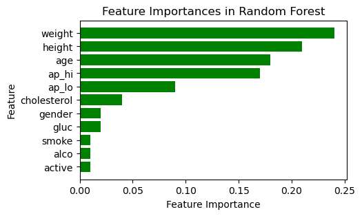

```python
# Plotting the feature importances
plt.figure(figsize=(5,3))
plt.barh(feature_imp_df["Variable"], feature_imp_df["Importance"], color='green')
plt.xlabel("Feature Importance")
plt.ylabel("Feature")
plt.title("Feature Importances in Random Forest")
plt.gca().invert_yaxis()  # Highest importance at the top
plt.show()
```

### Key Findings

**Top Contributing Features:**

- Weight (0.24): The most important feature, suggesting that weight is the strongest predictor in your model.
- Height (0.21): The second most important feature, indicating a significant contribution to the model’s predictions.
- Age (0.18): Also highly important, showing that age is a key factor in the predictions

**Moderately Important Features:**

- ap_hi (0.17): Systolic blood pressure has a notable influence on the model, making it an important predictor.
- ap_lo (0.09): Diastolic blood pressure has a moderate impact on the model’s performance.

**Less Important Features:**

- Cholesterol (0.04): This feature contributes less compared to the top predictors but still has some impact.
- Gender (0.02) and Gluc (0.02): These features have minimal influence on the model.
- Smoke (0.01), Alco (0.01), and Active (0.01): These features are the least important in the model, indicating that their influence on the predictions is very small.

**Interpretation**

**Health Metrics:** Variables such as weight, height, age, and blood pressure (ap_hi and ap_lo) are significant predictors in the Random Forest model. These findings align with common medical knowledge, where these metrics are critical indicators of various health conditions.

**Lifestyle Factors:** Features like smoking status (smoke), alcohol consumption (alco), and physical activity (active) are less influential in this model. This could be due to a variety of reasons, such as lower variability in the dataset for these factors or their lesser direct impact on the outcome being predicted.

**Medical Metrics:** Cholesterol and glucose levels (gluc) have some influence but are not as critical as the top features. This might suggest that while these metrics are relevant, they are not the primary drivers of the model’s predictions.

**Conclusion** The Random Forest model has identified that weight, height, and age are the most influential features in predicting the outcome. Blood pressure readings also play a significant role, while lifestyle factors like smoking and alcohol consumption have minimal impact. These insights can help focus on the most critical features for predictive modeling and potentially guide further data collection or feature engineering efforts.